# Notes on scheduling the SAA2019 meeting

Ben Marwick

27 October, 2017

## Introduction

In these notes I attempt to make a start on organising the conference sessions into time slots suitable for scheduling.

We have the individual submissions already organised into sessions. The task here is to identify the slots available and fit the sessions into them. Here’s what I’ve done:

First, we computed a suitable duration for each session, given the number of participants and the SAA policy about the maximum duration of the various session types.

Second, we assigned all non-poster sessions to the available four hour time slots. We tallied up the number of slots by looking at the ‘Room & Time’ spreadsheet.

Third, we spread the slots across the parts of each day of the meeting (morning, afternoon, evening), since each day has slightly different room resources available.

Fourth, we identified problems and schedule clashes, and what to do next.

## How many sessions do we have?

We have this many sessions in each major category:

| Session type | number |
| --- | --- |
| Organised sessions | 214 |
| Poster sessions | 18 |
| General sessions | 58 |

With a total of 290 sessions altogether, and a total number of non-poster sessions 272.

For scheduling into rooms and time slots, we wont include the posters, because they go in their own schedule in the ballroom.

## How many 4 hour slots do we have available?

To find out how many 4 h slots we have available, I looked on the grid on ‘Rooom&Time_DG.xlsx’ and counted up the 4 slots. I did not count poster sessions here, because they are less than 4 h and they are outside of the room schedule. I rounded down a little:

- Thur afternoon has the ethics bowl from 1-3 pm, so I removed one whole 4 h slot from that part
- Fri morning has some time reserved from 9am-12 pm with the note “Reserved for Business Meeting after 12:00pm”, so removed one whole 4 h slot from that part also

Here’s what I got for session slots in each day and part of day:

| part | Th | Fr | Sa | Su |
| --- | --- | --- | --- | --- |
| morning | 36 | 31 | 30 | 28 |
| afternoon | 35 | 32 | 30 | 0 |
| evening | 36 | 0 | 0 | 0 |

So that’s a total of 258 4 hour slots, in which we have to fit all the organised and general sessions. This does not include the posters.

## What are the durations of the sessions?

We need to set the upper bounds for the session durations, according to the SAA rules, and then compute how much time each session is likely to take give the number of papers/speakers, if that is less than the allowed time.

The plot below shows the distribution of papers across all non-poster session:

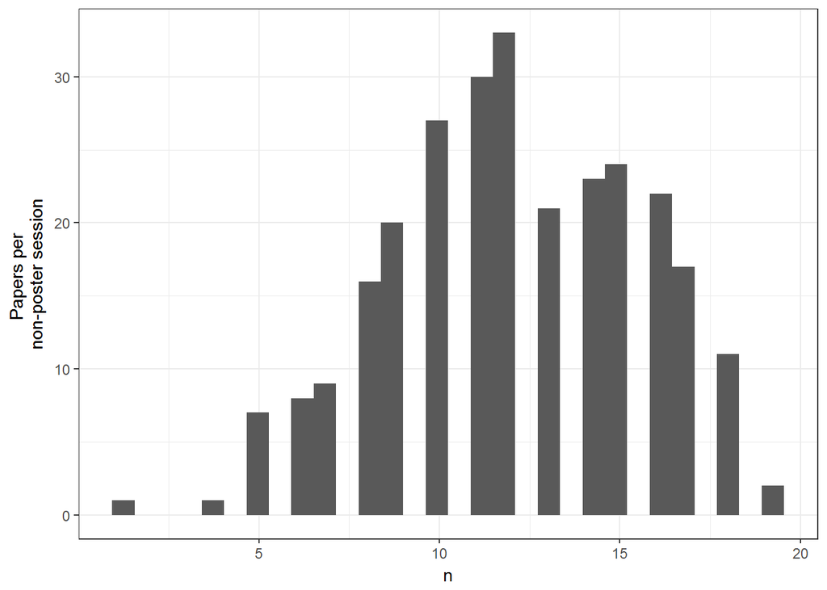

QUESTION! Do we need to split the sessions with more than 16 papers? If we have a four hour slot, and 15 minutes per paper, the maximum number of papers that can be done in 4 hours is 16. So what do we do about the sessions with 17 to 19? Split them into two? Let the organisors work out that they need to shorten the papers in their session?

Here are the SAA rules for the duration of each session type:

| Session Type | saa_allowed_time |
| --- | --- |
| Poster Symposium | 2 |
| Symposium | 4 |
| Electronic Symposium | 2 |
| Forum | 2 |
| Lightning Rounds | 2 |

Here we take the SAA rules for the duration of each session type, and if a session has more than 16 papers, we simply assign the duration of that session the maximum allowed time according to the SAA rules. We also compute the ‘anticipated duration’ of each session by taking the number of papers and mulitplying by 15 minutes. This is most relevant for the ‘symposium’ types, because other session types don’t always have paper presentations. But we apply the upper duration to all sessions for now to ensure they all follow the SAA rules about duration.

The plot below shows how a bunch of sessions have had their durations change according the following rules:

- round up each session duration to the nearest 0.25 hour, for convienence, since it’s awkward to have sessions starting and ending at odd times
- shorten sessions to fit into the SAA rules of 2 and 4 h, depending on the session type
- for very small sessions, set a minumum duration of 1.5, because that’s what most session organisers wil be expecting

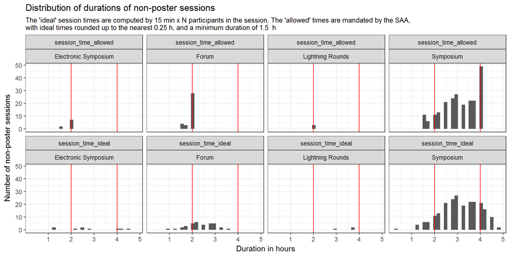

QUESTION! Do we include the chair, discussant and moderators in the N of people in each session? Or only the number of abstracts per session? I think that we must, because in fora there are only discussants, so that’s what I’ve done.

QUESTION! If there are a very small number of paricipants in a session, do we allocate the SAA-imposed limit to that session? Or do we allow smaller sessions to have shorter durations, for example schedule 1 hour for 4 people? That seems unfair, so I’ve set a minimum duration of 1.5 h for all sessions, since that’s what most session chairs will be expecting. I’ve also rounded up the durations to the nearest 0.25 min

## How to distribute the sessions in the 4 hour slots?

Now we have computed durations for all the sessions, we can try to find the optimum way to squeeze them into the slots available.

This question is combinatorial optimization question, more specifically, it is type of multiple knapsack problem. Given a set of resources (i.e. sessions of various lengths), how do we allocate them to a give number of time slots (all the same size, four hours)? Once we solve that problem, then we will distribute these slots across the day-parts.

To get started on this, we can use Rasmus Bååth’s nice case study of the the multiple knapsack problem (http://www.sumsar.net/blog/2016/06/how-to-cut-your-planks-with-r/).

Let’s put the result back onto the data frame of all the non-poster sessions so we can see which sessions can go in the same slot.

| Session Id | Session Type | saa_allowed_time | n | session_time_ideal | session_time_allowed | computed_slot |
| --- | --- | --- | --- | --- | --- | --- |
| 21 | Symposium | 4 | 6 | 1.5 | 1.5 | 3 |
| 2988 | Symposium | 4 | 6 | 1.5 | 1.5 | 17 |
| 3084 | Forum | 2 | 6 | 1.5 | 1.5 | 42 |
| 3098 | Forum | 2 | 6 | 1.5 | 1.5 | 67 |
| 3102 | Symposium | 4 | 6 | 1.5 | 1.5 | 70 |
| 3139 | Symposium | 4 | 6 | 1.5 | 1.5 | 77 |

Now that we have assigned sessions to slots, we need to join this slot information onto the data frame of each individual paper. This is necessary so we can ensure that we don’t put one person in two places at once when we distribute the slots across the day-parts on the schedule.

# How to avoid putting one person in two places at once?

We make a unique ID out of the first name and last name to track individuals.

We assign slots to day-parts, then we join this day-part data back to the data frame of individual papers.

The table below shows a snippet of how the slots available are distributed across the day-parts:

| day_part | from_slot | to_slot |
| --- | --- | --- |
| Th-morning | 1 | 36 |
| Th-afternoon | 37 | 71 |
| Th-evening | 72 | 107 |
| Fr-morning | 108 | 138 |
| Fr-afternoon | 139 | 170 |
| Sa-morning | 171 | 200 |

Now we take the computed slot values for each session that we got from the multiple knapsack function and put the sessions into day-parts. This table shows a snippet of the computed slots assigned to day-parts:

| computed_slot | day_part | from_slot | to_slot |
| --- | --- | --- | --- |
| 1 | Th-morning | 1 | 36 |
| 2 | Th-morning | 1 | 36 |
| 3 | Th-morning | 1 | 36 |
| 4 | Th-morning | 1 | 36 |
| 5 | Th-morning | 1 | 36 |
| 6 | Th-morning | 1 | 36 |

Now we join the day-parts onto the individual sessions and then the individual abstracts by the computed slot values.

And now we can plot one possible configuration of the sessions as a grid of sessions for each block of time on the schedule:

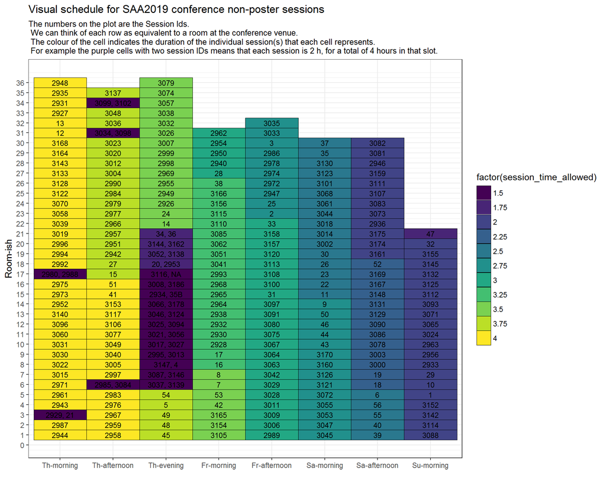

Now let’s identify problems where one person is in two different sessions in the same day-part (i.e. column in the plot above).

In the data frame of individual papers, we check that the UID does not occur in more than one session ID for one day-part (it can occur twice on one session ID).

This plot shows sessions where one person is currently scheduled to be in two places at one (the red cells indicate the clashing sessions):

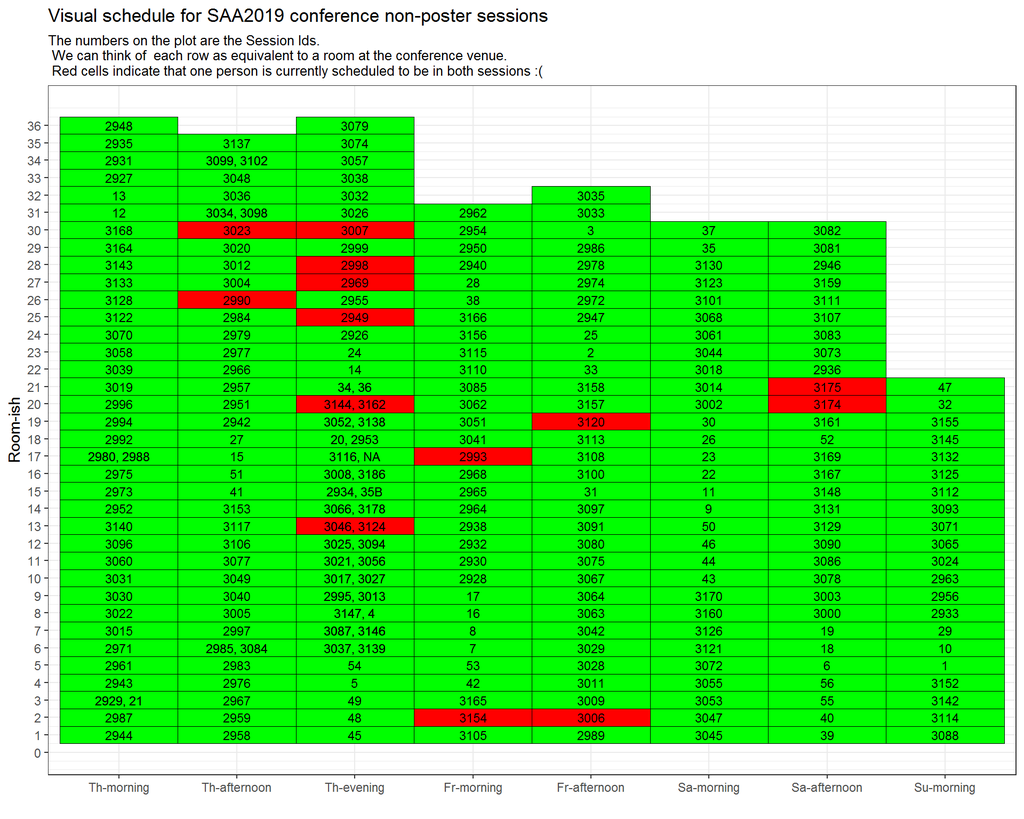

## How can we prevent one person scheduled in two simultaneous sessions?

If we treat each day-part as one knapsack, and then loop over filling the knapsack to check if a name has already been added, and if it has, skip that day-part and move to the next, and check that next pay-part to see if the name is already there.

We can compute the total capacity of each day-part in hours like this:

| day_part | slot | total_capacity |
| --- | --- | --- |
| Th-morning | 36 | 144 |
| Th-afternoon | 35 | 140 |
| Th-evening | 36 | 144 |
| Fr-morning | 31 | 124 |
| Fr-afternoon | 32 | 128 |
| Sa-morning | 30 | 120 |
| Sa-afternoon | 30 | 120 |
| Su-morning | 28 | 112 |

Now we will take session from the big table of sessions and add them into, for example, Th-morning until we reach the capacity of that day-part. But, we also need to loop over the sessions as we add more to the day-part to check to see if a person’s name is already there or not.

```r
output <- vector("list", nrow(total_cap))

# get all the sessions, but we're going to modify this, so make a copy
z7 <- z6
all_of_the_day_parts <- NULL
total_cap$hours_of_sessions <- 0
i <- 1

# start with each day-part...
for(i in seq_len(nrow(total_cap))) {
  target_capacity <- total_cap$total_capacity[i] - 4

  # prepare a while statement that will take a session,
  # check to see if there is a name clash with sessions,
  # skip adding it if there is clash, then check to see
  # the culumative duration of the sessions in the day-part
  # has exceeeded the total duration of the day-part,
  # and stop adding sessions if it has.
cumulative_duration_of_sessions   <-  0
container_for_this_day_part <- 0
all_the_people_in_the_session <- 0
j <- 1

while(cumulative_duration_of_sessions <= target_capacity &
      j <= nrow(z7)) {

    get_a_session <- z7[j, ]

    # get the names of all the people in this session...
    all_the_people_in_this_session <-
      left_join(get_a_session,
                all_nonposter_papers_with_day_parts,
                by = "Session Id")

    # check how many times each name appears
     if (j == 1) {
      # do nothing is this is the first incoming session
       distinct_names_for_each_session_so_far <- 0
    } else {
      # get distinct names for each session previously added
      # to this day-part
      # (don't care about same name multiple times in one session)
      distinct_names_for_each_session_so_far <-
      container_for_this_day_part %>%
        group_by(uid) %>%
        distinct(uid, .keep_all = TRUE)
    }

    if (j == 1) {
      # do nothing
      names_already_in <- 0
      } else {
      # check to see if incoming session has names that already exist in this day_part
      names_already_in <- sum(all_the_people_in_this_session$uid
                              %in% distinct_names_for_each_session_so_far$uid)
      }


    if (j == 1) {
       container_for_this_day_part <-
        all_the_people_in_this_session
      } else {
      if (names_already_in == 0) {
      # if there are no name clashes,
      # add these names to previous names in this day-part

      container_for_this_day_part <-
        bind_rows(all_the_people_in_this_session,
                  container_for_this_day_part)
    }  else {

        # do not add this session to the day-part
      container_for_this_day_part <-
        all_the_people_in_this_session
      }
    }

    # bind rows of session that has no clashing  names with
    # sessions we already added to this day-part
    cumulative_duration_of_sessions <-
      container_for_this_day_part %>%
      distinct(`Session Id`, .keep_all = TRUE) %>%
      pull(session_time_allowed.x) %>%
      sum

    # store this result
    total_cap$hours_of_sessions[i] <- cumulative_duration_of_sessions

    # move to the next session
    print(paste0("j = ", j))
    print(paste0("cumulative duration = ", cumulative_duration_of_sessions))
    print(paste0("number of sessions added = ", length(unique(container_for_this_day_part$`Session Id`))))
    j <- j + 1

    }
# end of the while


 # for the next day-part, we need to make sure
 # we don't add the same session twice to different day-parts
 # so let's update our big table of abstracts, and drop the session that
 # we've already got in the day-part

 z7 <-
   z7 %>%
   filter(! `Session Id` %in% unique(container_for_this_day_part$`Session Id`))


 # add an identifier so we can see where we have assigned each session so far
 container_for_this_day_part$day_part_from_while  <- total_cap$day_part[i]

 # bind rows to previous day-parts we might have done
  if (i == 1) {

  all_of_the_day_parts <- container_for_this_day_part

  } else {

    # check to see

  all_of_the_day_parts <- bind_rows(container_for_this_day_part,
                                      all_of_the_day_parts)

  }

 print(paste0("i = ", i))

}
```

## Summary

Now we have a rough draft of the schedule of non-poster sessions. We used the multiple knapsack algorithm to distribute the sessions efficiently across the available sessions. This method identifies combinations of sessions that are <4 h and then combines these shorter sessions to fill the 4 h slots.

We still have some things to do:

- Resolve the clashes that currently have one person in two sessions at the same time. I’m thinking of how it can be done programatically, but nothing obvious has occured to me.
- Assign the sessions to specific times and rooms. Perhaps this is best be done manually?
- Consider all of the conflicts and special requests in ‘Conflicts.docx’
- Repeat all of this for the posters. This could be done with some minor variations to the code used here.

### Colophon

This report was generated on 2017-10-27 08:11:19 using the following computational environment and dependencies:

```
#>  setting  value
#>  version  R version 3.4.1 (2017-06-30)
#>  system   x86_64, mingw32
#>  ui       RTerm
#>  language (EN)
#>  collate  English_Australia.1252
#>  tz       America/Los_Angeles
#>  date     2017-10-27
#>
#>  package      * version    date       source
#>  adagio       * 0.6.5      2016-05-29 CRAN (R 3.4.1)
#>  assertthat     0.2.0      2017-04-11 CRAN (R 3.4.0)
#>  backports      1.1.0      2017-05-22 CRAN (R 3.4.0)
#>  base         * 3.4.1      2017-06-30 local
#>  bindr          0.1        2016-11-13 CRAN (R 3.4.0)
#>  bindrcpp     * 0.2        2017-06-17 CRAN (R 3.4.0)
#>  broom          0.4.2      2017-02-13 CRAN (R 3.4.0)
#>  cellranger     1.1.0.9000 2017-05-31 Github (rsheets/cellranger@024d5ba)
#>  colorspace     1.3-2      2016-12-14 CRAN (R 3.4.0)
#>  compiler       3.4.1      2017-06-30 local
#>  datasets     * 3.4.1      2017-06-30 local
#>  devtools       1.13.3     2017-08-02 CRAN (R 3.4.1)
#>  digest         0.6.12     2017-01-27 CRAN (R 3.4.0)
#>  dplyr        * 0.7.4      2017-09-28 CRAN (R 3.4.2)
#>  evaluate       0.10.1     2017-06-24 CRAN (R 3.4.0)
#>  forcats        0.2.0      2017-01-23 CRAN (R 3.4.0)
#>  foreign        0.8-69     2017-06-21 CRAN (R 3.4.0)
#>  fuzzyjoin    * 0.1.3      2017-06-19 CRAN (R 3.4.0)
#>  ggplot2      * 2.2.1.9000 2017-10-24 Github (tidyverse/ggplot2@ffb40f3)
#>  glue           1.1.1      2017-06-21 CRAN (R 3.4.0)
#>  graphics     * 3.4.1      2017-06-30 local
#>  grDevices    * 3.4.1      2017-06-30 local
#>  grid           3.4.1      2017-06-30 local
#>  gtable         0.2.0      2016-02-26 CRAN (R 3.4.0)
#>  haven          1.1.0      2017-07-09 CRAN (R 3.4.1)
#>  hms            0.3        2016-11-22 CRAN (R 3.4.0)
#>  htmltools      0.3.6      2017-04-28 CRAN (R 3.4.0)
#>  httr           1.3.1      2017-08-20 CRAN (R 3.4.1)
#>  jsonlite       1.5        2017-06-01 CRAN (R 3.4.0)
#>  kableExtra   * 0.6.0      2017-10-24 CRAN (R 3.4.2)
```

[output cut: 27 more lines]

```
#>  scales         0.5.0.9000 2017-09-07 Github (hadley/scales@d767915)
#>  stats        * 3.4.1      2017-06-30 local
#>  stringi        1.1.5      2017-04-07 CRAN (R 3.4.0)
#>  stringr        1.2.0      2017-02-18 CRAN (R 3.4.0)
#>  tibble       * 1.3.4      2017-08-22 CRAN (R 3.4.1)
#>  tidyr        * 0.7.1      2017-09-01 CRAN (R 3.4.1)
#>  tidyselect     0.2.0      2017-08-30 CRAN (R 3.4.1)
#>  tidyverse    * 1.1.1      2017-01-27 CRAN (R 3.4.1)
#>  tint           0.0.3      2016-10-16 CRAN (R 3.4.2)
#>  tools          3.4.1      2017-06-30 local
#>  utils        * 3.4.1      2017-06-30 local
#>  viridisLite    0.2.0      2017-03-24 CRAN (R 3.4.0)
#>  withr          2.0.0      2017-10-24 Github (jimhester/withr@a43df66)
#>  xml2           1.1.1      2017-01-24 CRAN (R 3.4.1)
#>  yaml           2.1.14     2016-11-12 CRAN (R 3.4.0)
```

The current Git commit details are:

```
#> Local:    master C:/Users/bmarwick/Desktop/saaabstracts/
#> Remote:   master @ origin (https://github.com/benmarwick/saaabstracts.git)
#> Head:     [3f11900] 2017-10-26: merge conflict resolution
```